# Layer3 - L3 Claims Are Now LIVE

# L3 Bonus Claim For 5,600 Wallets

## Bonus is 2% of total supply.

[interactive chart not shown]

# Quests tell your story

Design your own combination of onchain & offchain actions for users to take.

## How it works

01 Work with us to define your goals

02 We bring your Quest campaign to life

03 You see real-time impact and onchain analytics

[figure not shown]

# Drive engagement and retention natively

Embed one-time or recurring quests directly in your product with 2 lines of code.

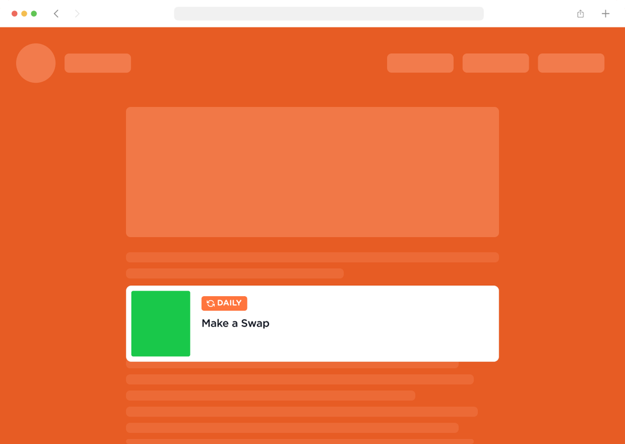

# Packed with features

[figure not shown]

## Multichain Support

Across EVM chains, Solana, Cosmos and more

[figure not shown]

## Flexible Reward Types

Reward your users with NFTs, Tokens, XP and Achievements

[figure not shown]

## Instant Verification

Your users' onchain actions are verified in real-time

[figure not shown]

## Onchain & Offchain

Extensive action types to reach and retain users

[figure not shown]

## Co-Marketing

Promote your brand alongside Layer3

[figure not shown]

## Campaign analytics

Powerful reports to optimise performance

# Storytelling delivers results

# 20M+

Onchain actions

# 750k+

Unique users

# 100+

Partners

"Layer3 has played an important role in the successful launch of Base by designing and supporting user quests in the Base ecosystem. Their platform offers easy-to-use, essential tools for acquiring and retaining users through engaging interactive experiences."

[figure not shown]

Base

"Layer3 is the best platform to build and engage communities through gamified education. Supported by an excellent team and sleek design, this much needed concept is truly a great way to bring users into the crypto ecosystem."

[figure not shown]

Hashflow

"Layer3 stands out among Web3 acquisition platforms for its engaged and high-quality community. Paired with their thoughtful curation and amazing team, Layer3 is helping accelerate web3 adoption in a much needed way."

[figure not shown]

Phantom

"The team at Layer3 and their intuitive, engaging Quests were the perfect match to help increase awareness of WOOFi’s cutting-edge cross-chain swaps and single-sided staking."

[figure not shown]

WOOFi

# Get in touch

[figure not shown]

[interactive chart not shown]